# US Opioid Prescriber Analysis

2022-06-18

### Data Preparation

The original data sets used for this project can be downloaded from the following websites: Medicare Part D Prescribers - by Provider and Drug: https://data.cms.gov/provider-summary-by-type-of-service/medicare-part-d-prescribers/medicare-part-d-prescribers-by-provider-and-drug/data

Medicare Part D Prescribers - by Geography and Drug: https://data.cms.gov/provider-summary-by-type-of-service/medicare-part-d-prescribers/medicare-part-d-prescribers-by-geography-and-drug/data

We also referenced code in Kaggle script below for preparing the final data set for further analysis: https://raw.githubusercontent.com/apryor6/apryor6.github.io/master/Identifying-Opioid-Prescribers/create-dataset.R.

A copy of the final data set to a csv file and used in the following analysis.

### Exploratory and Descriptive Analysis

```r
# read final prescriber data set created above
prescriber <- read.csv('prescriber_2019.csv')
prescriber_final <- prescriber
str(prescriber_final)
```

```
## 'data.frame':    971968 obs. of  254 variables:
##  $ PRSCRBR_NPI                   : int  1003000126 1003000142 1003000167 1003000282 1003000423 1003000522 1003000530 1003000597 1003000720 1003000746 ...
##  $ PRSCRBR_STATE_ABRVTN          : chr  "MD" "OH" "NV" "TN" ...
##  $ PRSCRBR_TYPE                  : chr  "Internal Medicine" "Anesthesiology" "Dentist" "Nurse Practitioner" ...
##  $ ACETAMINOPHEN.WITH.CODEINE    : int  0 27 0 0 0 0 0 0 0 0 ...
##  $ ACYCLOVIR                     : int  0 0 0 0 0 0 0 0 0 0 ...
##  $ ALBUTEROL.SULFATE             : int  0 0 0 0 0 37 101 0 0 0 ...
##  $ ALCOHOL.ANTISEPTIC.PADS       : int  0 0 0 0 0 0 0 0 0 0 ...
##  $ ALENDRONATE.SODIUM            : int  0 0 0 0 0 22 120 0 0 0 ...
##  $ ALLOPURINOL                   : int  0 0 0 12 0 63 57 0 0 0 ...
##  $ ALPRAZOLAM                    : int  0 0 0 0 0 155 57 0 0 0 ...
##  $ AMIODARONE.HCL                : int  13 0 0 0 0 13 0 0 0 0 ...
##  $ AMITRIPTYLINE.HCL             : int  0 0 0 0 0 0 0 0 0 0 ...
##  $ AMLODIPINE.BESYLATE           : int  22 0 0 0 0 208 310 0 12 0 ...
##  $ AMLODIPINE.BESYLATE.BENAZEPRIL: int  0 0 0 0 0 0 20 0 0 0 ...
```

[output cut: 86 more lines]

```r
#check if the data set is complete
nrow(prescriber_final[!complete.cases(prescriber_final),])
```

```
## [1] 0
```

```r
#0 means there are no incomplete rows
```

```r
#convert prescriber NPI to factor
prescriber_final$PRSCRBR_NPI <- as.factor(list(prescriber_final$PRSCRBR_NPI))

#convert character variables to factors
prescriber_final <- prescriber_final %>%
  mutate_if(is.character, funs(as.factor))
#convert output variable to factor
prescriber_final$OPIOD_PRESC <- as.factor(prescriber_final$OPIOD_PRESC)
```

First, we reviewed how many prescriber types are included in the data set.

```r
str(prescriber_final$PRSCRBR_TYPE)
```

```
##  Factor w/ 183 levels "","Acupuncturist",..: 75 10 39 106 108 51 75 181 106 130 ...
```

As shown above, the data set includes 183 different prescriber types.

We then checked how many states are included.

```r
str(prescriber_final$PRSCRBR_STATE_ABRVTN)
```

```
##  Factor w/ 61 levels "AA","AE","AK",..: 26 42 40 50 42 14 45 43 34 39 ...
```

The data set includes information for 61 “states”, which are 50 United States, District of Columbia, U.S. territories, Armed Forces areas, Unknown and Foreign Country. For our analysis, we will remove the Unknown and Foreign Country records and use information of the remaining 59 “states”.

```r
# remove Unknown and Foreign Country records that are belong to states XX and ZZ
prescriber_final_new<-prescriber_final[!(prescriber_final$PRSCRBR_STATE_ABRVTN %in% c("XX","ZZ")),]

prescriber_final_new$PRSCRBR_STATE_ABRVTN <- as.character(prescriber_final_new$PRSCRBR_STATE_ABRVTN)
prescriber_final_new$PRSCRBR_STATE_ABRVTN <- as.factor(prescriber_final_new$PRSCRBR_STATE_ABRVTN)

str(prescriber_final_new$PRSCRBR_STATE_ABRVTN)
```

```
##  Factor w/ 59 levels "AA","AE","AK",..: 26 42 40 50 42 14 45 43 34 39 ...
```

```r
#review the number of records in the new data set
nrow(prescriber_final_new)
```

```
## [1] 971862
```

We also created a subset of data that only includes opiate drugs to conduct exploratory and descriptive analyses.

```r
#select only basic information and data for opiate drugs
prescriber_final_slim <- prescriber_final_new[,c("PRSCRBR_STATE_ABRVTN", "PRSCRBR_TYPE", "ACETAMINOPHEN.WITH.CODEINE",  "MORPHINE.SULFATE", "TRAMADOL.HCL","HYDROMORPHONE.HCL", "METHADONE.HCL", "FENTANYL", "OXYCODONE.HCL.ACETAMINOPHEN", "HYDROCODONE.ACETAMINOPHEN", "OXYCODONE.HCL","TOPIRAMATE","OPIOD_PRESC")]

# create another subset that only includes opiate prescriber
opioid_prescriber <- prescriber_final_slim[prescriber_final_slim$OPIOD_PRESC  == TRUE,]

# create another subset that only includes non-opiate prescriber
non_opioid_prescriber <- prescriber_final_slim[prescriber_final_slim$OPIOD_PRESC  == FALSE,]
```

```r
# calculate the proportion of the non-opioid precriber
nrow(non_opioid_prescriber)/nrow(prescriber_final_slim)
```

```
## [1] 0.5865771
```

Around 59% of the prescribers never prescribed opiate drugs before.

```r
#add new column that summarizes the total opioids prescriptions
opioid_prescriber$TOTAL_PRESCRIPTIONS <- rowSums(opioid_prescriber[,c(3:12)])
```

```r
#check the statistics of the Total Prescriptions variable
summary(opioid_prescriber$TOTAL_PRESCRIPTIONS)
```

```
##    Min. 1st Qu.  Median    Mean 3rd Qu.    Max.
##    11.0    21.0    49.0   152.6   133.0 30911.0
```

Per results above, the distribution of total number of opioid prescriptions written by opioid prescribers is extremely right skewed with a median of 49.0 and mean of 152.6.

We wanted to check the top 10 opioid prescribers by total number of prescriptions.

```r
opioid_prescriber[,c('PRSCRBR_STATE_ABRVTN','PRSCRBR_TYPE','TOTAL_PRESCRIPTIONS')] %>%
  arrange(-TOTAL_PRESCRIPTIONS) %>%
  head(10)
```

```
##    PRSCRBR_STATE_ABRVTN                         PRSCRBR_TYPE
## 1                    LA       Interventional Pain Management
## 2                    KY Physical Medicine and Rehabilitation
## 3                    FL                       Anesthesiology
## 4                    FL Physical Medicine and Rehabilitation
## 5                    GA       Interventional Pain Management
## 6                    FL                       Anesthesiology
## 7                    FL                      Pain Management
## 8                    FL       Interventional Pain Management
## 9                    TX       Interventional Pain Management
## 10                   FL       Interventional Pain Management
##    TOTAL_PRESCRIPTIONS
## 1                30911
## 2                22642
## 3                19635
## 4                18009
## 5                17676
## 6                17611
## 7                16878
## 8                16550
## 9                16414
## 10               15862
```

As shown above, an individual from LA issued more that 30,000 total number of opioid prescriptions in 2019, which was significantly more than all other prescribers in the entire US.

```r
#Group the prescriber data by Prescriber Type
groupedByPrescriber <- opioid_prescriber %>%
  group_by(PRSCRBR_TYPE) %>%
  summarise(Total_Prescriber_Count=n(), Total_Opioids_Count = sum(TOTAL_PRESCRIPTIONS)) %>%
  arrange(-Total_Opioids_Count)

#check the top prescriber types with highest total prescription amounts
groupedByPrescriber %>%
  arrange(-Total_Opioids_Count) %>%
  head()
```

```
## # A tibble: 6 × 3
##   PRSCRBR_TYPE                         Total_Prescriber_Count Total_Opioids_Cou…
##   <fct>                                                 <int>              <dbl>
## 1 Family Practice                                       68446           14204488
## 2 Internal Medicine                                     55475           11211513
## 3 Nurse Practitioner                                    59813            8398411
## 4 Physician Assistant                                   40303            4946870
## 5 Physical Medicine and Rehabilitation                   4983            2678222
## 6 Anesthesiology                                         2632            2526980
```

The top three prescriber types by total number of opioid prescriptions were Family Practice, Internal Medicine and Nurse Practitioner.

We then checked what were the top three prescriber types by average number of opioid prescriptions. The average was calculated from total number of prescriptions divided by total number of prescribers.

```r
#create a column for average number of opioids prescription per prescriber
groupedByPrescriber$Avg_Opioids_Count <- round(groupedByPrescriber$Total_Opioids_Count / groupedByPrescriber$Total_Prescriber_Count)

groupedByPrescriber %>%
  arrange(-Avg_Opioids_Count) %>%
  head()
```

```
## # A tibble: 6 × 4
##   PRSCRBR_TYPE             Total_Prescriber_… Total_Opioids_Co… Avg_Opioids_Cou…
##   <fct>                                 <int>             <dbl>            <dbl>
## 1 Interventional Pain Man…               1488           2365802             1590
## 2 Pain Management                        2153           2512417             1167
## 3 Anesthesiology                         2632           2526980              960
## 4 Durable Medical Equipme…                  1               694              694
## 5 Pain Medicine                            53             30047              567
## 6 Physical Medicine and R…               4983           2678222              537
```

This time, we identified another unusual case. Durable medical equipment & medical supplies specialty had only one opioid prescriber in 2019, but the average number of opioid prescriptions this person wrote ranked the fourth among all specialties.

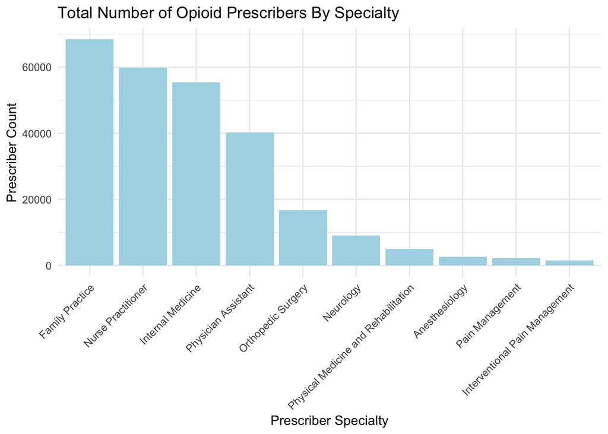

```r
bp_groupedByPrescriber <- groupedByPrescriber[1:10,] %>%
  mutate(PRSCRBR_TYPE = fct_reorder(PRSCRBR_TYPE, -Total_Prescriber_Count)) %>%
  ggplot(aes(x=PRSCRBR_TYPE, y=Total_Prescriber_Count)) +
  geom_bar(stat="identity", fill="lightblue")+
  theme_minimal()+
  ggtitle("Total Number of Opioid Prescribers By Specialty") +
  labs(x = "Prescriber Specialty", y = "Prescriber Count")+
  theme(axis.text.x = element_text(angle = 45, hjust = 1))

bp_groupedByPrescriber
```

We then reviewed the prescriber and prescription data by State.

```r
#summarize the total number of prescriptions for each opioid by State
groupedByState <- aggregate(cbind(ACETAMINOPHEN.WITH.CODEINE,  MORPHINE.SULFATE, TRAMADOL.HCL,HYDROMORPHONE.HCL, METHADONE.HCL, FENTANYL, OXYCODONE.HCL.ACETAMINOPHEN, HYDROCODONE.ACETAMINOPHEN, OXYCODONE.HCL,TOPIRAMATE,TOTAL_PRESCRIPTIONS)~PRSCRBR_STATE_ABRVTN, data = opioid_prescriber, sum)

groupedByState %>%
  arrange(-TOTAL_PRESCRIPTIONS) %>%
  head()
```

```
##   PRSCRBR_STATE_ABRVTN ACETAMINOPHEN.WITH.CODEINE MORPHINE.SULFATE TRAMADOL.HCL
## 1                   CA                     282903           279206       910054
## 2                   FL                     122676           323259       994728
## 3                   TX                     697238           134804      1342432
## 4                   PA                      83137           138770       583742
## 5                   NC                      25710           104368       544709
## 6                   MI                     146452           121961       431460
##   HYDROMORPHONE.HCL METHADONE.HCL FENTANYL OXYCODONE.HCL.ACETAMINOPHEN
## 1             71694         91512    84357                      487176
## 2             84556         66781   111533                      896972
## 3             41657         40209    90900                      141471
## 4             23229         24701    89284                      383310
## 5             26864         33917    54001                      466708
## 6             15893         36284    65061                      193871
##   HYDROCODONE.ACETAMINOPHEN OXYCODONE.HCL TOPIRAMATE TOTAL_PRESCRIPTIONS
## 1                   2600201        375337     178006             5360446
## 2                   1253123        563014     169815             4586457
## 3                   1609133        138317     155053             4391214
## 4                    554362        521727     156354             2558616
## 5                    717179        431951     113845             2519252
## 6                   1188947        138946      98040             2436915
```

The top three States by total number of opioid prescriptions were CA, FL and TX.

### Association Rule Mining

**Data Preprocessing**

We first performed the Association Rule Mining analysis. The goal of the Association Rule Mining is to explore relations between Prescriber Type and Drug information, more specifically which opioids are most likely to be prescribed by certain types of medical professionals. Therefore, we conducted the research using only opioid prescribers and opiate drugs data.

First, we reviewed the opioid prescriber data again.

```r
summary(opioid_prescriber)
```

```
##  PRSCRBR_STATE_ABRVTN              PRSCRBR_TYPE    ACETAMINOPHEN.WITH.CODEINE
##  CA     : 40791       Family Practice    : 68446   Min.   :   0.000
##  TX     : 28081       Nurse Practitioner : 59813   1st Qu.:   0.000
##  FL     : 23264       Internal Medicine  : 55475   Median :   0.000
##  NY     : 21188       Physician Assistant: 40303   Mean   :   6.046
##  PA     : 18141       Emergency Medicine : 24151   3rd Qu.:   0.000
##  OH     : 16123       Dentist            : 20785   Max.   :3064.000
##  (Other):254202       (Other)            :132817
##  MORPHINE.SULFATE    TRAMADOL.HCL     HYDROMORPHONE.HCL  METHADONE.HCL
##  Min.   :   0.000   Min.   :   0.00   Min.   :   0.000   Min.   :   0.000
##  1st Qu.:   0.000   1st Qu.:   0.00   1st Qu.:   0.000   1st Qu.:   0.000
##  Median :   0.000   Median :  12.00   Median :   0.000   Median :   0.000
##  Mean   :   7.295   Mean   :  32.42   Mean   :   1.718   Mean   :   1.876
##  3rd Qu.:   0.000   3rd Qu.:  38.00   3rd Qu.:   0.000   3rd Qu.:   0.000
##  Max.   :4221.000   Max.   :3910.00   Max.   :1015.000   Max.   :1389.000
##
##     FENTANYL        OXYCODONE.HCL.ACETAMINOPHEN HYDROCODONE.ACETAMINOPHEN
##  Min.   :   0.000   Min.   :   0.00             Min.   :    0
##  1st Qu.:   0.000   1st Qu.:   0.00             1st Qu.:    0
##  Median :   0.000   Median :   0.00             Median :   16
##  Mean   :   3.544   Mean   :  20.54             Mean   :   54
##  3rd Qu.:   0.000   3rd Qu.:  15.00             3rd Qu.:   45
##  Max.   :1032.000   Max.   :8081.00             Max.   :12961
##
##  OXYCODONE.HCL       TOPIRAMATE       OPIOD_PRESC    TOTAL_PRESCRIPTIONS
##  Min.   :   0.00   Min.   :   0.000   FALSE:     0   Min.   :   11.0
##  1st Qu.:   0.00   1st Qu.:   0.000   TRUE :401790   1st Qu.:   21.0
##  Median :   0.00   Median :   0.000                  Median :   49.0
##  Mean   :  18.51   Mean   :   6.679                  Mean   :  152.6
##  3rd Qu.:  12.00   3rd Qu.:   0.000                  3rd Qu.:  133.0
##  Max.   :7057.00   Max.   :2033.000                  Max.   :30911.0
##
```

As shown above, all drug variables are numeric and are extremely right skewed (means are far greater than the medians). Therefore, we would like to convert them to factors by discretizing those variables into customized bins.

```r
#create a function to discretize drug counts into customized bins
split_drugcount <- function(name,df){
df[,name] <-  cut(df[,name], breaks = c(-1,0,10,100,1000,2000,4000,Inf),labels=c("0", "0-10","10-100","100-1000","1000-2000","2000-4000", "Above 4000"))
return(df)
}

#create another function to discretize drug counts into different customized bins
split_drugcount2 <- function(name,df){
df[,name] <-  cut(df[,name], breaks = c(-1,10,500,1000,2000,4000,Inf),labels=c( "0-10","10-500","500-1000","1000-2000","2000-4000", "Above 4000"))
return(df)
}

#create another function to discretize drug counts into different customized bins
split_drugcount3 <- function(name,df){
df[,name] <-  cut(df[,name], breaks = c(-1,10,100,500,1000,Inf),labels=c( "0-10","10-100","100-500","500-1000","Above 1000"))
return(df)
}
```

We tried using different customized bins, and found out the second one above performed the best results. Therefore, the following analysis will be conducted by applying that discretization function. We also tried to discretize those drug variables into equal-length bins, but found out more meaningful rules could be generated if using customized bins.

```r
#save a copy of the data in a new variable
opioid_prescriber_arm <- opioid_prescriber

#create the data set that only includes prescriber state, prescriber type and opiate drugs
opioid_prescriber_arm <- opioid_prescriber_arm[,1:12]
str(opioid_prescriber_arm)
```

```
## 'data.frame':    401790 obs. of  12 variables:
##  $ PRSCRBR_STATE_ABRVTN       : Factor w/ 59 levels "AA","AE","AK",..: 26 42 14 45 43 23 10 9 41 43 ...
##  $ PRSCRBR_TYPE               : Factor w/ 183 levels "","Acupuncturist",..: 75 10 51 75 181 51 51 122 135 117 ...
##  $ ACETAMINOPHEN.WITH.CODEINE : int  0 27 0 0 0 0 0 31 0 0 ...
##  $ MORPHINE.SULFATE           : int  0 33 0 0 0 35 0 530 11 0 ...
##  $ TRAMADOL.HCL               : int  0 62 49 26 19 76 0 439 11 0 ...
##  $ HYDROMORPHONE.HCL          : int  0 0 0 0 0 0 0 42 0 0 ...
##  $ METHADONE.HCL              : int  0 0 0 0 0 0 0 49 0 0 ...
##  $ FENTANYL                   : int  0 14 0 18 0 0 0 165 0 0 ...
##  $ OXYCODONE.HCL.ACETAMINOPHEN: int  14 97 0 0 12 0 0 712 0 79 ...
##  $ HYDROCODONE.ACETAMINOPHEN  : int  0 143 43 57 157 37 0 917 0 63 ...
##  $ OXYCODONE.HCL              : int  0 54 0 23 0 0 13 576 0 40 ...
##  $ TOPIRAMATE                 : int  0 0 0 0 0 13 0 14 0 0 ...
```

```r
#perform discretization by applying the function split_drugcount2 to the data
final_opiate_drugs_list <- list('ACETAMINOPHEN.WITH.CODEINE', 'MORPHINE.SULFATE', 'TRAMADOL.HCL', 'HYDROMORPHONE.HCL', 'METHADONE.HCL', 'FENTANYL', 'OXYCODONE.HCL.ACETAMINOPHEN', 'HYDROCODONE.ACETAMINOPHEN', 'OXYCODONE.HCL', 'TOPIRAMATE')

for (name in final_opiate_drugs_list) {
  opioid_prescriber_arm <- split_drugcount2(name,opioid_prescriber_arm)
}

#review the new data frame
summary(opioid_prescriber_arm)
```

```
##  PRSCRBR_STATE_ABRVTN              PRSCRBR_TYPE    ACETAMINOPHEN.WITH.CODEINE
##  CA     : 40791       Family Practice    : 68446   0-10      :328693
##  TX     : 28081       Nurse Practitioner : 59813   10-500    : 73001
##  FL     : 23264       Internal Medicine  : 55475   500-1000  :    82
##  NY     : 21188       Physician Assistant: 40303   1000-2000 :    13
##  PA     : 18141       Emergency Medicine : 24151   2000-4000 :     1
##  OH     : 16123       Dentist            : 20785   Above 4000:     0
##  (Other):254202       (Other)            :132817
##    MORPHINE.SULFATE      TRAMADOL.HCL     HYDROMORPHONE.HCL
##  0-10      :351402   0-10      :182845   0-10      :381835
##  10-500    : 49754   10-500    :218159   10-500    : 19926
##  500-1000  :   518   500-1000  :   716   500-1000  :    28
##  1000-2000 :   103   1000-2000 :    60   1000-2000 :     1
##  2000-4000 :    12   2000-4000 :    10   2000-4000 :     0
##  Above 4000:     1   Above 4000:     0   Above 4000:     0
##
##     METHADONE.HCL          FENTANYL      OXYCODONE.HCL.ACETAMINOPHEN
##  0-10      :381952   0-10      :362654   0-10      :274489
##  10-500    : 19789   10-500    : 39089   10-500    :125082
##  500-1000  :    44   500-1000  :    46   500-1000  :  1582
##  1000-2000 :     5   1000-2000 :     1   1000-2000 :   515
##  2000-4000 :     0   2000-4000 :     0   2000-4000 :   108
##  Above 4000:     0   Above 4000:     0   Above 4000:    14
##
##  HYDROCODONE.ACETAMINOPHEN    OXYCODONE.HCL         TOPIRAMATE
##  0-10      :151575         0-10      :289653   0-10      :328696
##  10-500    :243994         10-500    :110103   10-500    : 73032
##  500-1000  :  4288         500-1000  :  1479   500-1000  :    57
##  1000-2000 :  1478         1000-2000 :   484   1000-2000 :     3
##  2000-4000 :   373         2000-4000 :    65   2000-4000 :     2
##  Above 4000:    82         Above 4000:     6   Above 4000:     0
##
```

The final data frame only includes information for 401,790 opioid prescribers.

**Data mining** Next, we performed association rule mining on the data set using the apriori function in the arules package. We started with generating rules that have a minimum support of 0.10, and a minimum confidence of 0.8.

```r
a <- Sys.time()

#generate rules using arules package and apriori function
rules <- apriori(opioid_prescriber_arm, parameter = list(supp = 0.10, conf = 0.80, minlen = 2,maxlen=2))
```

```
## Apriori
##
## Parameter specification:
##  confidence minval smax arem  aval originalSupport maxtime support minlen
##         0.8    0.1    1 none FALSE            TRUE       5     0.1      2
##  maxlen target  ext
##       2  rules TRUE
##
## Algorithmic control:
##  filter tree heap memopt load sort verbose
##     0.1 TRUE TRUE  FALSE TRUE    2    TRUE
##
## Absolute minimum support count: 40179
##
## set item appearances ...[0 item(s)] done [0.00s].
## set transactions ...[237 item(s), 401790 transaction(s)] done [0.23s].
## sorting and recoding items ... [22 item(s)] done [0.02s].
## creating transaction tree ... done [0.22s].
## checking subsets of size 1 2
```

```
##  done [0.00s].
## writing ... [88 rule(s)] done [0.00s].
## creating S4 object  ... done [0.07s].
```

```r
difftime(Sys.time(),a)
```

```
## Time difference of 0.7479291 secs
```

Rules were generated in a second.

```r
# Show the rules that have a lift value greater or equal to a value
goodrules <- rules[quality(rules)$lift > 1]

# show the rules that have prescriber type on the left hand side
rules_subset <- subset(goodrules, (lhs %in% paste0("PRSCRBR_TYPE=", unique(opioid_prescriber_arm$PRSCRBR_TYPE))))
inspect(rules_subset)
```

```
##     lhs                                  rhs                                 support confidence  coverage     lift count
## [1] {PRSCRBR_TYPE=Nurse Practitioner} => {ACETAMINOPHEN.WITH.CODEINE=0-10} 0.1297743  0.8717503 0.1488663 1.065616 52142
## [2] {PRSCRBR_TYPE=Nurse Practitioner} => {METHADONE.HCL=0-10}              0.1420892  0.9544748 0.1488663 1.004049 57090
## [3] {PRSCRBR_TYPE=Family Practice}    => {TRAMADOL.HCL=10-500}             0.1371438  0.8050580 0.1703527 1.482700 55103
```

As shown above, only three rules that had prescriber type on the left hand side had a lift value greater than 1. Then, we adjusted the support and confidence thresholds to include more rules.

```r
a <- Sys.time()

rules2 <- apriori(opioid_prescriber_arm, parameter = list(supp = 0.03, conf = 0.70, minlen = 2,maxlen=2))
```

```
## Apriori
##
## Parameter specification:
##  confidence minval smax arem  aval originalSupport maxtime support minlen
##         0.7    0.1    1 none FALSE            TRUE       5    0.03      2
##  maxlen target  ext
##       2  rules TRUE
##
## Algorithmic control:
##  filter tree heap memopt load sort verbose
##     0.1 TRUE TRUE  FALSE TRUE    2    TRUE
##
## Absolute minimum support count: 12053
##
## set item appearances ...[0 item(s)] done [0.00s].
## set transactions ...[237 item(s), 401790 transaction(s)] done [0.23s].
## sorting and recoding items ... [37 item(s)] done [0.03s].
## creating transaction tree ... done [0.26s].
## checking subsets of size 1 2
```

```
##  done [0.01s].
## writing ... [241 rule(s)] done [0.00s].
## creating S4 object  ... done [0.08s].
```

```r
difftime(Sys.time(),a)
```

```
## Time difference of 0.7702329 secs
```

```r
# Show the rules that have a lift value greater or equal to 1
goodrules2 <- rules2[quality(rules2)$lift > 1]

# show the rules that have prescriber type as left hand side
rules_subset2 <- subset(goodrules2, (lhs %in% paste0("PRSCRBR_TYPE=", unique(opioid_prescriber_arm$PRSCRBR_TYPE))))
inspect(rules_subset2)
```

```
##      lhs                                   rhs                                   support confidence   coverage     lift count
## [1]  {PRSCRBR_TYPE=General Surgery}     => {TOPIRAMATE=0-10}                  0.03037159  0.9901818 0.03067274 1.210374 12203
## [2]  {PRSCRBR_TYPE=General Surgery}     => {MORPHINE.SULFATE=0-10}            0.03051345  0.9948069 0.03067274 1.137454 12260
## [3]  {PRSCRBR_TYPE=General Surgery}     => {FENTANYL=0-10}                    0.03053087  0.9953749 0.03067274 1.102791 12267
## [4]  {PRSCRBR_TYPE=General Surgery}     => {HYDROMORPHONE.HCL=0-10}           0.03030937  0.9881532 0.03067274 1.039795 12178
## [5]  {PRSCRBR_TYPE=General Surgery}     => {METHADONE.HCL=0-10}               0.03059061  0.9973223 0.03067274 1.049122 12291
## [6]  {PRSCRBR_TYPE=Orthopedic Surgery}  => {HYDROCODONE.ACETAMINOPHEN=10-500} 0.03064536  0.7392975 0.04145200 1.217417 12313
## [7]  {PRSCRBR_TYPE=Orthopedic Surgery}  => {ACETAMINOPHEN.WITH.CODEINE=0-10}  0.03510043  0.8467727 0.04145200 1.035084 14103
## [8]  {PRSCRBR_TYPE=Orthopedic Surgery}  => {TOPIRAMATE=0-10}                  0.04137485  0.9981387 0.04145200 1.220100 16624
## [9]  {PRSCRBR_TYPE=Orthopedic Surgery}  => {MORPHINE.SULFATE=0-10}            0.04091441  0.9870309 0.04145200 1.128563 16439
## [10] {PRSCRBR_TYPE=Orthopedic Surgery}  => {FENTANYL=0-10}                    0.04126285  0.9954368 0.04145200 1.102860 16579
## [11] {PRSCRBR_TYPE=Orthopedic Surgery}  => {HYDROMORPHONE.HCL=0-10}           0.03975460  0.9590513 0.04145200 1.009172 15973
## [12] {PRSCRBR_TYPE=Orthopedic Surgery}  => {METHADONE.HCL=0-10}               0.04133751  0.9972381 0.04145200 1.049033 16609
## [13] {PRSCRBR_TYPE=Dentist}             => {TRAMADOL.HCL=0-10}                0.04842828  0.9361559 0.05173100 2.057142 19458
## [14] {PRSCRBR_TYPE=Dentist}             => {OXYCODONE.HCL.ACETAMINOPHEN=0-10} 0.04882650  0.9438537 0.05173100 1.381589 19618
```

[output cut: 27 more lines]

After reviewing the 41 rules generated above, we found 5 most interesting rules and they were put in the final report.

We also did additional research to check if we can find relations between State and Drug information.

```r
a <- Sys.time()

rules3 <- apriori(opioid_prescriber_arm, parameter = list(supp = 0.01, conf = 0.70, minlen = 2,maxlen=2))
```

```
## Apriori
##
## Parameter specification:
##  confidence minval smax arem  aval originalSupport maxtime support minlen
##         0.7    0.1    1 none FALSE            TRUE       5    0.01      2
##  maxlen target  ext
##       2  rules TRUE
##
## Algorithmic control:
##  filter tree heap memopt load sort verbose
##     0.1 TRUE TRUE  FALSE TRUE    2    TRUE
##
## Absolute minimum support count: 4017
##
## set item appearances ...[0 item(s)] done [0.00s].
## set transactions ...[237 item(s), 401790 transaction(s)] done [0.21s].
## sorting and recoding items ... [70 item(s)] done [0.03s].
## creating transaction tree ... done [0.27s].
## checking subsets of size 1 2
```

```
##  done [0.02s].
## writing ... [455 rule(s)] done [0.00s].
## creating S4 object  ... done [0.09s].
```

```r
difftime(Sys.time(),a)
```

```
## Time difference of 0.7865741 secs
```

```r
# Show the rules that have a lift value greater or equal to a value
goodrules3 <- rules3[quality(rules3)$lift > 1]

# show the rules that have prescriber type as left hand side
rules_subset3 <- subset(goodrules3, (lhs %in% paste0("PRSCRBR_STATE_ABRVTN=", unique(opioid_prescriber_arm$PRSCRBR_STATE_ABRVTN))))
inspect(rules_subset3[1:30])
```

```
##      lhs                          rhs                                   support confidence   coverage     lift count
## [1]  {PRSCRBR_STATE_ABRVTN=KS} => {HYDROMORPHONE.HCL=0-10}           0.01012220  0.9549190 0.01060006 1.004824  4067
## [2]  {PRSCRBR_STATE_ABRVTN=AR} => {HYDROMORPHONE.HCL=0-10}           0.01017447  0.9538031 0.01066726 1.003650  4088
## [3]  {PRSCRBR_STATE_ABRVTN=IA} => {METHADONE.HCL=0-10}               0.01043829  0.9568789 0.01090868 1.006578  4194
## [4]  {PRSCRBR_STATE_ABRVTN=CT} => {ACETAMINOPHEN.WITH.CODEINE=0-10}  0.01043082  0.8812027 0.01183703 1.077171  4191
## [5]  {PRSCRBR_STATE_ABRVTN=CT} => {MORPHINE.SULFATE=0-10}            0.01048558  0.8858284 0.01183703 1.012849  4213
## [6]  {PRSCRBR_STATE_ABRVTN=CT} => {FENTANYL=0-10}                    0.01071206  0.9049622 0.01183703 1.002622  4304
## [7]  {PRSCRBR_STATE_ABRVTN=CT} => {METHADONE.HCL=0-10}               0.01145623  0.9678301 0.01183703 1.018098  4603
## [8]  {PRSCRBR_STATE_ABRVTN=OK} => {HYDROMORPHONE.HCL=0-10}           0.01143134  0.9598746 0.01190921 1.010038  4593
## [9]  {PRSCRBR_STATE_ABRVTN=OK} => {METHADONE.HCL=0-10}               0.01147117  0.9632184 0.01190921 1.013246  4609
## [10] {PRSCRBR_STATE_ABRVTN=AL} => {HYDROCODONE.ACETAMINOPHEN=10-500} 0.01121979  0.7366013 0.01523184 1.212977  4508
## [11] {PRSCRBR_STATE_ABRVTN=AL} => {OXYCODONE.HCL=0-10}               0.01259862  0.8271242 0.01523184 1.147339  5062
## [12] {PRSCRBR_STATE_ABRVTN=AL} => {ACETAMINOPHEN.WITH.CODEINE=0-10}  0.01291720  0.8480392 0.01523184 1.036632  5190
## [13] {PRSCRBR_STATE_ABRVTN=AL} => {MORPHINE.SULFATE=0-10}            0.01370119  0.8995098 0.01523184 1.028492  5505
## [14] {PRSCRBR_STATE_ABRVTN=AL} => {HYDROMORPHONE.HCL=0-10}           0.01480873  0.9722222 0.01523184 1.023031  5950
```

[output cut: 16 more lines]

Unfortunately, no interesting rules were generated based on results above. Association rule mining may not be a good technique to analyze relations between State and Drug Name/Prescription Amount.

### Conclusion

The rules identified suggest that if the prescriber is practicing family practice, he or she is around 81% likely to prescribe Tramadol 10-500 times a year, and around 74% likely to prescribe Hydrocodone Acetaminophen 10-500 times a year. If the prescriber is practicing internal medicine, he or she is around 78% likely to prescribe Tramadol 10-500 times a year. If the prescriber is practicing orthopedic surgery or emergency medicine, he or she is around 73% likely to prescribe Hydrocodone Acetaminophen 10-500 times a year.

The results from the Association Rule Mining may be used by the government authority to monitor which specialties are most likely to prescribe opioids at high dosages. We also reviewed rules that have the State name on the left-hand side but did not find any interesting results. Association Rule Mining may not be a good technique to analyze relations between State and drug name/prescription amount.